# Week 1, Notes & Exercises

Statistical Thinking (ETC2420 / ETC5242)

Published

Semester 2, 2025

# Introduction

This tutorial provides a hands-on introduction to R and RStudio. It complements the material on [StartR](https://startr.numbat.space/), acting both as revision and extension of that content.

The structure of this tutorial is typical of what you will do over the semester. You will need to think about how to manipulate a given dataset, how to visualise it effectively, and what you can learn from it. To start with, we focus mostly on developing your knowledge of R and programming skills. As the semester progresses, we will shift emphasis to learn and practice statistical concepts and skills.

**Learning Goals for Week 1**

- Use **R** and **RStudio** on your own device.
- Learn to install and load **R packages**.
- Learn about **Quarto** files and reproducible research.
- Learn about the **tidyverse**.
- Learn some basic R commands to manipulate and plot data.
- Compose your own answers to questions and render a document for submission.
- Learn how to diagnose errors.

If you are already a confident user of R and RStudio, this introduction will be straightforward. You will finish quickly and can use your time to expand your capabilities through the later StartR modules, or investigate other resources. You can also use this introduction as a reference later in the unit.

If you are an R beginner, or need a refresher, take you time to work through each part of this tutorial. Perhaps make a list of the different packages or commands as you learn them, and note on which tutorial or other reference on which they appear so that you can find them again when you need to do something similar later on.

For everyone, as the unit progresses, you are encouraged to explore beyond what the tasks dictate; a willingness to experiment will make you a much better programmer and data analyst. It will also give you the space to be able to think beyond the code, and to appreciate that having a computational perspective can really help you to *understand* data and the relevance (and limitations!) of modern statistics/econometrics/actuarial/analytics techniques.

Once you have both R and RStudio installed, you are ready to start the tutorial activities. So let’s begin with the fundamental building blocks of R and RStudio: the interface, reading in data, and some basic commands.

# Launch RStudio and create a Project

Go ahead and launch RStudio.

## Project

A project in RStudio is essentially a folder that contains all the relevant files in one place. With the help of the project, you don’t need to worry about whether the file you want to open is in the current working directory (the place you are working at).

Create a project for this unit. Go to **File** and then **New Project**. Select **New Directory** if you want to create a new folder to contain you files, or select **Existing Directory** if you want to use an existing folder.

Be sure to create a data folder; call it `data`, to stick with convention. It is up to you how you set up the directories. You could create a folder for each week; if so, then also create a `data` folder in each one.

Remember to open this project every time you want to work on this unit. We recommend **not** saving the “Workspace image” (the data you have loaded, the functions you have defined, etc.) when you quit R or switch to a different project, so you can have a fresh start next time you open RStudio.

## Packages

We will use the `tidyverse` and `tinytex` packages (you should have seen these in the StartR module), and we will always use them. It is probably the first thing that you should add to your Quarto file – more on this below.

### The tinytex package

The `tinytex` package enables us to generate publication quality documents directly to PDF. It also allows us to use LaTeX to create equations in our documents. The LaTeX commands also work if we render to HTML, but we need an extra step to convert this to PDF. Rendering directly to PDF is our strong preference in this unit.

The `tinytex` package can be somewhat temperamental (and takes a while to install). If you have any issues, please attend a consultation and we will try and help you. Please do not ask for help with tinytex in the tutorial, we will not have enough time to diagnose the problem. Simply render to HTML.

### The tidyverse package

The `tidyverse` package is actually a suite of packages, including those that are designed for data wrangling and data visualisation. These packages share common philosophies and are designed to work together. Over time the packages contained within the tidyverse have changed. You can find more about the packages in the tidyverse at https://www.tidyverse.org/.

The other packages in the tidyverse are more specialised, but we will use several of them occasionally, including:

- `purrr`: Primarily useful when you need to do apply the same function to every element of a list.
- `stringr`: For manipulating strings (sets of characters).
- `forcats`: A toolbox for manipulating categorical variables.

## Install the packages

Throughout the unit we will need more packages. Sometimes this will just be to use a specialised function. So we need to learn how to install a new package.

If tidyverse is not already available in your R environment, install it by typing the following line of code into the *Console* pane of your RStudio session. (You do not need to install the package again if it is already installed.)

```r
install.packages("tidyverse")
```

Note: You may need to select a server from which to download; any of the servers should work.

You can find the list of installed package names listed in the RStudio *Packages* pane. Notice a description of the package and the installed version number is also listed.

*An R tip:* In the code above you’ll notice that there is an opening bracket and a closing bracket. Similarly, the quotation marks (`"`) come in pairs. RStudio tries to help you out here by colouring anything inside the quotation marks a different colour. And if you put your cursor near a bracket, its pair should be highlighted. This will be useful later when we want to do more than one thing at a time.

## Load package libraries

Next, you need to load the `tidyverse` package into your current session (you shouldn’t need to load the `tinytex` package, but you can if you wish). We do this with the `library()` function. Run the following lines in your *Console* pane:

```r
library(tidyverse)
```

You always need to load a package before you can use any of the functions in it. This has to be done every time you start a new RStudio session. If you forget to do this, R will complain because it won’t be able to find the function you’re looking for.

(R complains a lot. This might be discouraging at first, but don’t take it personally. It’s only a computer system so it is not smart enough to work out everything on its own. Treat the warning and errors messages as reminders about steps that need to be done.)

Usually a package will only need to be installed on to your machine once, but you need to load them each time you start a new RStudio session. We typically use the console to install packages, and load packages in a code chunk at the beginning of our file (see “Load Arbuthnot’s dataset” below).

# Quarto

Throughout the semester, we will use **Quarto** files, which have a `.qmd` extension, to create *reproducible* tasks and assignments.

These tutorial notes are written in Quarto. For the assessment tasks, you will need to submit your Quarto file and your rendered file in PDF format.

## Create a new Quarto file

Go to: **File** → **New File** → **Quarto Document…**.

A window will pop up and your cursor should be on “Untitled”. There is also a space for the Author and below are selections for file types. In the title box, type “Tutorial 1” then OK.

The first few lines (delineated by `---`) are called the YAML header. This is where you can set document settings; refer to StartR for more info.

There will be some example text to show you some basic features of Quarto. Have a look if you haven’t seen it before, and then feel free to delete it.

Quarto has its own typesetting syntax. For example, the hash symbol `#` is used to denote section headings.

The Quarto cheatsheet is a handy reference:  
https://rstudio.github.io/cheatsheets/html/quarto.html

## Name and save your Quarto file

We recommend getting into the habit of using a standard format for your filenames. The convention we will require for all the work that you will submit looks like this:

> `tutorial01_IDnnnnnnnn.qmd`

with your Monash student ID number replacing the segment “`nnnnnnnn`” in the filename.

## Install the `knitr` package

You can render your Quarto file and produce either a HTML, DOCX or PDF version of your report. Behind the scenes, RStudio does this using the `knitr` package. If this isn’t already installed, you can install it using the same approach described earlier.

This time you may see a warning message, recommending that you let RStudio automatically restart R installing the package. Answer **Yes** to the question: *Do you want to restart R prior to installing?*

Once the installation is finished, click on the *Render* button, which you will see at the top of the *Editor* pane.

Today we will try to render to PDF (if you have `tinytex` installed), which will open the PDF file if successful.

If you don’t have `tinytex` installed, just render your file to the HTML format. When you press the *Render* button, a browser window might pop up to display your rendered report, or an **R viewer** (a browser-like window) might pop up instead. You can control which one it is by choosing *Preview in Window* or *Preview in Viewer Pane* in the drop-down menu just to the right of the *Render* button.

## Running code chunks within the Editor pane

If you you want to check whether a line of R code in a code chunk produces the desired result, you can:

- Run the entire chunk, by clicking on the green sideways triangle button in the top right corner of the code chunk, or
- Run selected code in the chunk, by highlighting the relevant lines of code and then clicking the button marked **Run** on the top right corner of the *Editor* pane.
- For other options, open the menu next to the **Run** button.

If at any point you need to refresh all of your calculations up to that point, you can *Run All Chunks Above* the chunk you’re working in by clicking on the down arrow in the code chunk.

## Keeping things neat

Now continue working through the rest of this document. Your first task will be to replicate some of these steps using another data set.

Please be sure that the answers you provide to each question are clearly labeled, and that the corresponding code chunk is also clearly identified. Marks will be given for neat and clear presentation for any submitted work.

# Dr. Arbuthnot’s baptism records

John Arbuthnot was a Scottish physician. In 1710 he published a paper[^1] that examined birth records in London for each of the 82 years from 1629 to 1710. Actually the data he used were counts of baptisms, by year and gender, but these are used as a proxy for the number of births.

The data from Arbuthnot’s study is contained in the file `arbuthnot.csv`, provided with these notes. It consists of three columns, named `year`, `boys` and `girls`. The `boys` and `girls` columns show the number of each that were born in London for each year as specified in the `year` column.

## Load Arbuthnot’s dataset

Save the file `arbuthnot.csv` to your project and put it in a folder called `data`.

In your Quarto file, create a new code chunk and add the following code:

```r
library(tidyverse)

arbuthnot <- read_csv("data/arbuthnot.csv")
```

### A note about code chunks

Code chunks are where Quarto knows to use R and put the results into our report. Notice that the chunk is shaded, this reminds us that this section is R code.

In Quarto, code chunks are created by typing 3 backticks (```) followed by “`r`” in curly brackets (no space), then 3 more backticks at the end of the chunk.

In the curly brackets, we can also add add a name and set various options. The chunk above is named `load-packages` (see this in the Quarto version of the notes). The options control how the code will be run and displayed when the document is rendered. Some of they key options are:

- `eval = TRUE` or `eval = FALSE`: Whether to run the code (the default) or not
- `echo = TRUE` or `echo = FALSE`: Whether to print the code (the default) or not
- `message = TRUE` or `message = FALSE`: Whether or not to print diagnostic messages generated by running the code.
- `error = TRUE` or `error = FALSE`: This specifies what to do if any errors occur. The default behaviour is `error = FALSE`, which stops the compilation every time you see an error. If you know the code has an error and you want the document to continue rendering anyway (for example, the purpose of the chunk is to demonstrate a particular error), you can set `error = TRUE`.

We can put any number of these options (and several others) together, separated by commas.

The settings for the chunk above will mean that during rendering it will:

- run the code chunk,
- print the code chunk in the output, and
- **not** print any diagnostic messages from R.

The code itself loads the `tidyverse` package, then creates a tibble called `arbuthnot` by reading in the CSV file. If all has gone well, you should see an entry called `arbuthnot` in your Environment tab in the top-right pane in RStudio, with 82 observations of 3 variables.

### Keeping your code

While you are working through the tutorial, you may want to compute quantities or create plots that are not directly related to an exercise. We suggest that you keep these code chunks but hide them from being rendered.

See examples below, in the Quarto versions of these notes.

## Tibbles

The `arbuthnot` object you have created is called a *tibble*. This is one of R’s most important data types and is used widely throughout the tidyverse. It holds *rectangular* or *tabular* data. That is, data where each row has the same number of entries, so it forms a “rectangle” with a particular number of rows and columns. Each column can be different types (numbers, strings, dates, etc.)

Tibbles are a relatively recent addition to R and comec from the `tibble` package, which is part of the tidyverse. For information, see [Chapter 10, in R for Data Science](https://r4ds.had.co.nz/tibbles.html).

*R tip*: Names are case-sensitive in R. That means you can refer to the above tibble by `arbuthnot`, but typing `Arbuthnot` will not work.

## The Viewer pane

View the `arbuthnot` tibble by clicking on it in the *Environment* pane. This will load into a *Viewer* pane in the upper-left part of RStudio, next to the *Editor* pane(s).

The `arbuthnot` tibble contains 82 rows and 3 columns. While you will be able to see four columns of numbers in the *Viewer* pane, the first column is not actually part of the tibble. Each row represents a different year, shown in the first column of the tibble, and the second and third columns contain the numbers of boys and girls (respectively) baptised in the year corresponding to the entry in column 1. Use the scrollbar on the right-hand side of the *Viewer* pane to examine the complete data set.

The format of the tibble is important. Each of the column entries in a given row relates to the same year, so the 82 rows correspond to 82 distinct *cases*. The three columns represent three different attributes of a case, or *variables*, namely the *year*, the number of *boys* baptised and the number of *girls* baptised.

You can close the data viewer by clicking on the “$\times$” in the Viewer tab.

## Take a ‘glimpse’ at the data

Another way to take a look at this tibble is to use the `glimpse()` function:

```r
glimpse(arbuthnot)
```

The `glimpse()` function does not change the format of the tibble, it merely uses the tibble as an input, and prints out an alternative format without modifying the tibble itself.

You could also include the above line of code in your file, inside a code chunk. Make sure it comes *after* the command that loads the dataset (you have to load the data before you can do something with it!).

## Print a variable

We can access a variable contained in a single column of a tibble using command such as:

```r
arbuthnot$boys
```

```
 [1] 5218 4858 4422 4994 5158 5035 5106 4917 4703 5359 5366 5518 5470 5460 4793
[16] 4107 4047 3768 3796 3363 3079 2890 3231 3220 3196 3441 3655 3668 3396 3157
[31] 3209 3724 4748 5216 5411 6041 5114 4678 5616 6073 6506 6278 6449 6443 6073
[46] 6113 6058 6552 6423 6568 6247 6548 6822 6909 7577 7575 7484 7575 7737 7487
[61] 7604 7909 7662 7602 7676 6985 7263 7632 8062 8426 7911 7578 8102 8031 7765
[76] 6113 8366 7952 8379 8239 7840 7640
```

This command will only show the number of boys baptised each year. The dollar sign (`$`) extracts the column of the tibble according to the name that follows it, in this case it takes the column `boys` from the tibble `arbuthnot`.

*RStudio tip:* When you are typing, you can often just type the first few characters and then press the tab key on your keyboard to complete the typing for you. When there are multiple options, they will pop up for you to see. Try typing `arbuthnot$` and then press the tab key. You should see the three column names come up as options.

Notice the way R has printed these data. When we looked at the complete tibble, we saw 82 rows, one on each line of the display. Now having extracted only a single column, the data are no longer structured in a table with other variables, and instead are displayed one after another. This object is an example of a *vector*, which is used to represent a set of numbers of the same type. R has added numbers in square brackets along the left-hand side of the printout to indicate locations within the vector. For example, 5218 follows `[1]`, indicating that 5218 is the first entry in the vector. And if [33] starts a line, then that would mean the first number on that line would represent the 33rd entry in the vector.

*Exercise 1*

1. What line of R code would you use to extract the vector containing just the counts of girls baptised? Would it be a good idea to print it in an assignment?

## Data visualisation

R has some powerful functions for making graphics easily. We can create a simple plot of the number of girls baptised per year with the command:

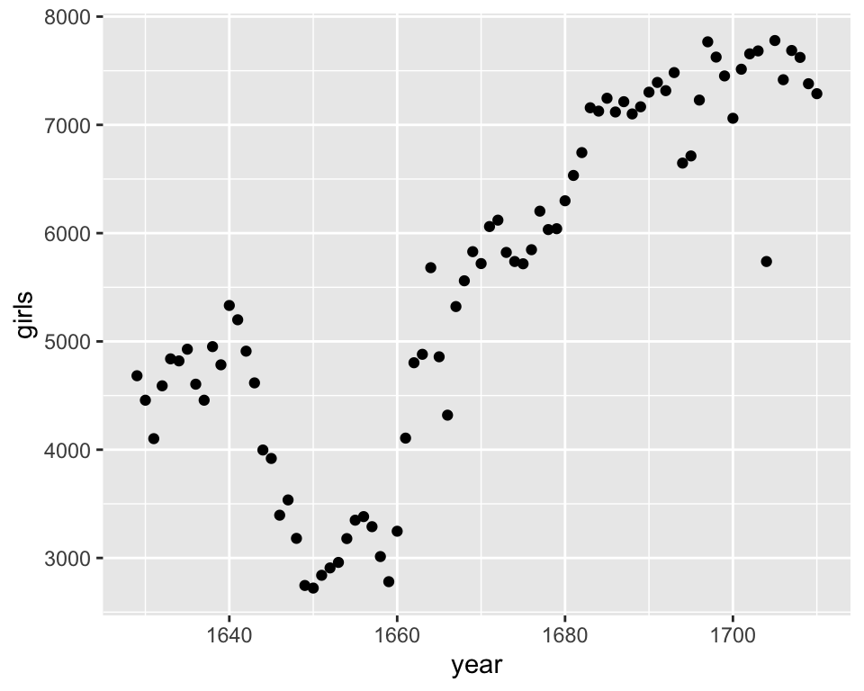

```r
ggplot(data = arbuthnot, aes(x = year, y = girls)) +
  geom_point()
```

We use the `ggplot()` function to build plots as follows:

- The first argument is always the dataset.
- Next, you specify how the variables from the dataset should be assigned to visual dimensions (“aesthetics”) of the plot, such as the x- and y-axes. You do this with the command: `aes(x = x_variable, y = y_variable)`.
- Finally, you specify geometric objects (“geoms”) to add to the plot. Somewhat unconventionally, these are added using the plus symbol (`+`). In this case, we want to create a scatter plot, so we draw points by using `geom_point()`. If you want a line plot instead, you would use `geom_line()`.

We can customise the visualisation further in many different ways. For example, to draw pink triangles instead of black circles, we would use: `geom_point(colour = "pink", shape = 17)`.

To find out more, a good reference is the ggplot2 cheat sheet: https://rstudio.github.io/cheatsheets/html/data-visualization.html

R also documents all of its functions extensively. To learn what a function does and its arguments that are available to you, just type in a question mark followed by the name of the function that you’re interested in. Try the following in your *Console*:

```r
?ggplot
```

Notice that the help file appears in the lower-right panel. You can toggle between plots and help files using the tabs at the top of that panel.

Finally, if you ever get stuck or get an error message that is confusing, you can usually find help online. Type the error message into Google and it will very often point you to the answer.

*Exercise 2*

2. Is there an apparent trend in the number of girls baptized over the years? How would you describe it? Are there any interesting features?

## R as a big calculator

Now, suppose we want to plot the total number of baptisms over time. To compute the total, we could use the fact that R is really just a big calculator. We can type in mathematical expressions like:

```r
5218 + 4683
```

to get the total number of baptisms in 1629. We could repeat this once for each year, but there is a faster way. If we add the *vector* of baptisms for boys to that of girls, R will compute *all* sums with only a single command.

```r
arbuthnot$boys + arbuthnot$girls
```

When you run this command, you will see it prints a vector containing 82 numbers, each one representing the sum we’re after for each year in the data set. (Take a look at a few of them and verify that they are right.)

Unfortunately, the command above doesn’t save the results. We could define a new object, using the command:

```r
total <- arbuthnot$boys + arbuthnot$girls
```

However, the vector named `total` created in the above code chunk would be completely separate from the original `arbuthnot` tibble. It would be more convenient to include the constructed `total` variable as another column in the tibble.

## Adding new variables to a tibble

Since we want to use this new `total` vector to generate some plots, we’ll want to save it as a new column in the `arbuthnot` tibble. We do this using the `mutate()` command from the `dplyr` package (loaded as part of the tidyverse). This is a useful function that will add new columns to a tibble that are constructed from the old columns.

We can do it as follows:

```r
arbuthnot <- mutate(arbuthnot, total = boys + girls)
```

It is possible to add several new columns at once. We just specify each one in turn, as a separate argument. For instance, if we also wanted a sex ratio (girls/boys), we could get that with:

```r
arbuthnot <- mutate(arbuthnot, total = boys + girls, ratio = girls / boys)
```

If we also wanted the proportion of girls, we could add that too:

```r
arbuthnot <- mutate(arbuthnot,
                    total      = boys + girls,
                    ratio      = girls / boys,
                    prop_girls = girls / total)
```

Notice that we used `total` as part of our definition of `prop_girls`. This works fine because `mutate()` evaluates the arguments in turn from left to right, which means the `total` column exists by the time we get to `prop_girls`. In contrast, the following version would generate an error because `total` doesn’t exist:

```r
arbuthnot <- mutate(arbuthnot,
                    prop_girls = girls / total,
                    total      = boys + girls,
                    ratio      = girls / boys)
```

In addition to simple mathematical operators like subtraction and division, you can ask R to make comparisons like greater than (`>`), less than (`<`), and equality (`==`). For example, we can ask if the number of births of boys outnumber that of girls in each year with the expression:

```r
arbuthnot <- mutate(arbuthnot, more_boys = boys > girls)
```

This command adds a new variable to the `arbuthnot` tibble containing the values `TRUE` or `FALSE` depending on whether the respective year had more boys than girls. This variable contains a different kind of data than we have encountered so far. All other columns in the `arbuthnot` tibble have values that are numerical (the year, and the number of boys and girls). Here, we have now asked R to create logical variables (also known as Boolean variables), which only have the values `TRUE` or `FALSE`. In general, data analysis will involve many different kinds of data types. One reason for using R is that it is easily able to represent and compute with many of them.

*Exercises 3–4*

3. Draw a line plot of the total number of baptisms per year.
4. How often were there more boys born than girls?

# Better R coding

## Coding in style

In some of the previous code chunks, we wrapped the code over several lines and indented the code to make it more readable. This is good practice, to help others (and your future self) easily understand your code.

There are a few things to remember when doing wrapping code:

- You can only wrap lines that are inside brackets. Otherwise R doesn’t know that there’s more coming.
- You should end every line with an indication that some more code is coming. Here we have a comma (`,`) at the end of each line, but a `+` or anything that requires something to the right of it will work.

Some other points of style to notice:

- All names are in lower case
- Words in the same name are separated by underscores (`_`)
- There are spaces on either side of operators (`+`, `/`, `<-`)
- There is one space to the right of each comma
- There is no space near brackets.

This might seem super pedantic and annoying, but it’s one of the most important but least flashy coding skills. Keeping consistent style that is easy to read is a core professional standard. The tidyverse style guide (https://style.tidyverse.org) is a handy reference that we recommend you follow when writing your R code.

## Simplicity via piping

An important element of modern R code is the %>% operator, which is called the *pipe operator*. Pretty much all of the commands above should be piped, to improve readability.

If you’ve never seen it before, it can seem like a bit of an odd beast. It does one simple thing: it takes the output of the expression on the left and inserts (“pipes”) it into the first argument of the function that follows it.

In the language of mathematical functions, $x$ %>% $f(y)$ is equivalent to $f(x, y)$.

For example, we could write that first mutate statement in the previous section as follows:

```r
arbuthnot <- arbuthnot %>% mutate(total = boys + girls)
```

Here’s how to interpret what the code is doing:

“Take the `arbuthnot` dataset and pipe it into the `mutate()` function. Mutate the `arbuthnot` tibble by creating a new variable, called `total`, that is the sum of the variables called `boys` and `girls`. Then assign the resulting tibble to the object called `arbuthnot`. In other words, overwrite the old `arbuthnot` tibble with the new version that contains the new variable.”

This is equivalent to going through each row and adding up the boys and girls counts for that year and recording that value in a new column called `total`.

The assignment operator (`<-`) takes the output of everything to the right of it and saves it into the object on its left. In this case, since we already have an object called `arbuthnot`, this command updates (overwrites) it with the version we obtain after running `mutate()`.

What makes the piping approach so powerful is that you can chain several pipes together.

For instance the following commands give the same output:

```r
# Version without piping.
arbuthnot_mutated <- mutate(arbuthnot, total = boys + girls, ratio = girls / boys)

# Version using piping.
arbuthnot_mutated <- arbuthnot %>%
  mutate(total = boys + girls) %>%
  mutate(ratio = girls / boys)
```

The code using pipes is easier to read because each line is doing a single step. We can read it as follows:

“Take `arbuthnot`, add a `total` column and then add a `ratio` column.”

## Commenting out code

The code chunk above shows how to add comments to code using `#`. This allows you to add any text to your code and R won’t try to run it.

One handy way to use this is to “turn off” any code that you no longer wish to run, but would like to retain for later. This is called “commenting out” the code.

```r
#arbuthnot$boys    <-- this code will not run
arbuthnot$girls  # <-- this code will run
```

```
 [1] 4683 4457 4102 4590 4839 4820 4928 4605 4457 4952 4784 5332 5200 4910 4617
[16] 3997 3919 3395 3536 3181 2746 2722 2840 2908 2959 3179 3349 3382 3289 3013
[31] 2781 3247 4107 4803 4881 5681 4858 4319 5322 5560 5829 5719 6061 6120 5822
[46] 5738 5717 5847 6203 6033 6041 6299 6533 6744 7158 7127 7246 7119 7214 7101
[61] 7167 7302 7392 7316 7483 6647 6713 7229 7767 7626 7452 7061 7514 7656 7683
[76] 5738 7779 7417 7687 7623 7380 7288
```

*Exercises 5–7*

5. Draw a plot of the proportion of boys born over time. What do you see?
6. Discuss this plot. Can it be improved?
7. Use the internet or help in R to create a **TERRIBLE** graph, which has none of the good attributes from exercise 6.

## Footnotes

[^1]: Arbuthnot, J. (1710). “An argument for divine providence, taken from the constant regularity observed in the births of both sexes,” , Vol 27, pp 186–190.